# Recap from yesterday

Sara Martino

sara.martino@ntnu.no

Dept. of Mathematical Science, NTNU

Janine Illian

Janine.Illian@glasgow.ac.uk

University of Glasgow

Jafet Belmont

Jafet.Belmont@glasgow.ac.uk

University of Glasgow

```r
# #| include: false

knitr::opts_chunk$set(echo = TRUE,
                      message=FALSE,
                      warning=FALSE,
                      strip.white=TRUE,
                      prompt=FALSE,
                      fig.align="center",
                       out.width = "60%")

library(knitr)    # For knitting document and include_graphics function
library(ggplot2)  # For plotting
library(png)
library(tidyverse)
library(INLA)
library(BAS)
library(patchwork)
library(DAAG)
library(inlabru)
library(fmesher)
library(cowplot) # needs install.packages("magick") to draw images
```

# The `inlabru` workflow

## The syntax

```r
# Define model components
comps <- component_1(...) +
  component_2(...) +
  ...

# Define the model predictor
pred <- linear_function(component_1,
                            component_2, ...)

# Build the observation model
lik <- bru_obs(formula = pred,
               family = ... ,
               data = ... ,
                ...)

# Fit the model
fit <- bru(comps, lik, ...)
```

**Components**

```r
~ my_component_name(
  main = ...,
  model = ...
)
```

- `my_component_name` how you label your component (.e.g, `beta_0`,`myspde`)
- `main` input data for the component (e.g., a the name of a column in your data or a spatial object)
- `model` The type of model component (e.g., `linear`,`fixed`,`iid`,`rw1`,`rw2`,`ar1`, see `?INLA::inla.list.models()$latent`)

## The syntax

```r
# Define model components
comps <- component_1(...) +
  component_2(...) +
  ...

# Define the model predictor
pred <- linear_function(component_1,
                            component_2, ...)

# Build the observation model
lik <- bru_obs(formula = pred,
               family = ... ,
               data = ... ,
                ...)

# Fit the model
fit <- bru(comps, lik, ...)
```

**linear predictor**

- can be defined within the formula:

```r
lik = bru_obs(formula =
                response ~  component_1(...) +
                component_2(...),
              family,
              data)
```

- or use a full stop shortcode after the componets have been defined

```r
lik = bru_obs(formula = y~.,
              family,
              data)
```

## The syntax

```r
# Define model components
comps <- component_1(...) +
  component_2(...) +
  ...

# Define the model predictor
pred <- linear_function(component_1,
                            component_2, ...)

# Build the observation model
lik <- bru_obs(formula = pred,
               family = ... ,
               data = ... ,
                ...)

# Fit the model
fit <- bru(comps, lik, ...)
```

**Likelihood**

Specify the distribution family (see `inla.list.models("likelihood")`)

```r
lik = bru_obs(formula,
              family  = "gaussian",
              data = df)
```

# Temporal Dependence

## Modelling temporal dependence

Data are often observed in time, and time dependence is often expected.

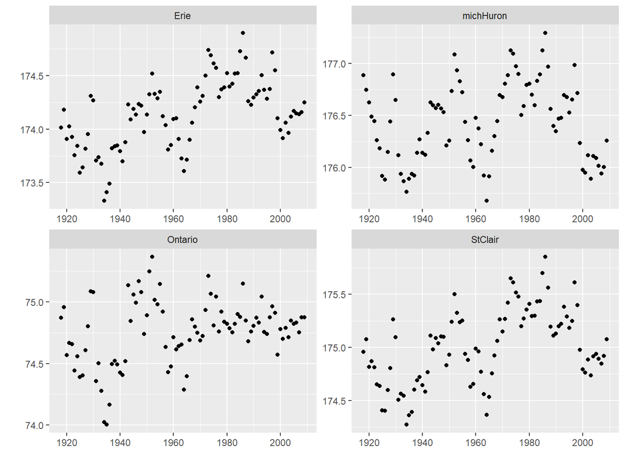

- Observations are correlated in time

## Motivation

Smoothing of the time effect

$$\begin{aligned}
y_t|\eta_t & \sim \text{N}(\mu,\tau_y^{-1})\\
\eta_t & = \mu = \beta_0 + u_t
\end{aligned}$$

The models we covered:

$$\begin{aligned}
1.\ u_t&\sim \text{RW}1(\tau)\\
2.\ u_t&\sim \text{RW}2(\tau)\\
3.\ u_t&\sim \text{AR}1(\tau, \phi)\\
\end{aligned}$$

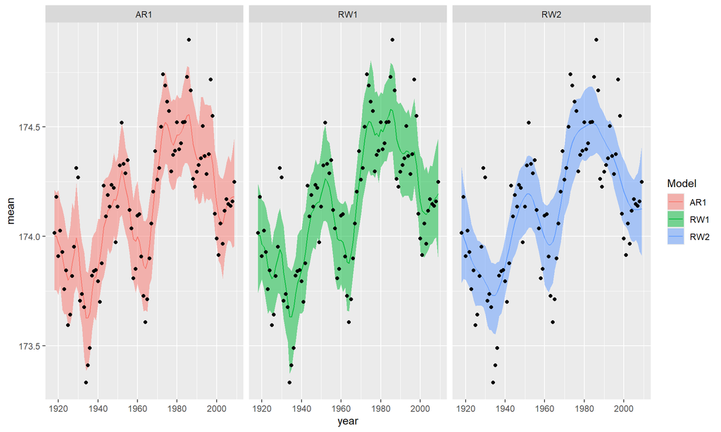

## Gaussian Markov Random Fields (GMRF)

A random vector $\mathbf{u} = (u_1, \ldots, u_n)^\top$ is a **Gaussian Markov Random Field (GMRF)** with respect to a graph $G = (V, E)$, with mean vector $\boldsymbol{\mu}$ and precision matrix $\mathbf{Q}$, if its probability density is

$$\pi(\mathbf{u}) =
|\mathbf{Q}|^{1/2}(2\pi)^{-n/2}
\exp\left\{
-\frac{1}{2}
(\mathbf{u}-\boldsymbol{\mu})^\top
\mathbf{Q}
(\mathbf{u}-\boldsymbol{\mu})
\right\}.$$

The precision matrix $\mathbf{Q}$ satisfies the Markov property:

$$Q_{ij} \neq 0
\quad \Longleftrightarrow \quad
\{i,j\} \in E, \qquad i \neq j.$$

Thus, conditional independence between two components $u_i$ and $u_j$, given all the remaining components, is encoded by zeros in the precision matrix:

$$u_i \perp u_j \mid \mathbf{u}_{-(i,j)}
\quad \Longleftrightarrow \quad
Q_{ij} = 0.$$

## Discrete time models

**Random Walks**

- *RW1*: Assume independent first-order increments $\Delta u_t = u_t − u_t−1 \sim N(0, \tau^{−1})$
- *RW2* Assume independent second-order increments $\Delta^2 u_t = u_t - u_{i-t} + u_{i-t} \sim N(0, \tau^{−1})$
- Intrinsic model $\rightarrow$ sum-to-zero constrain.

```r
cmp = ~ Intercept(1) +
  time(year, model = "rw1",
       constr = TRUE,
       hyper = list(prec =
                      list(prior = "pc.prec",
                           param = c(0.5, 0.5))))
```

- Small $\tau$ $\rightarrow$ large variation $\rightarrow$ less smooth effect
- Large $\tau$ $\rightarrow$ small variation $\rightarrow$ smoother effect
- PC-prior: $\text{Prob}(\sigma>U) = \alpha$ $\rightarrow$ penalize models with small precision or large variances (Baseline $\tau=0$).

**AR(1)**

- $u_t = \phi u_{t-1} + \epsilon_t; \qquad \phi\in(-1,1), \ \epsilon_t\sim\mathcal{N}(0,\tau^{-1})$

```r
pc_prior <- list(theta1 = list(prior = "pc.prec",
                              param = c(1, 0.01)),
                 rho = list(prior = "pc.cor0",
                            param = c(0.5, 0.3)))

cmp = ~ Intercept(1) +
  time(year, model = "ar1",
       hyper = pc_prior)
```

## Continuous time models

- Sometimes the data are not collected at discrete time points but over continuous time
- One solution (not a bad one usually) is to discretize the time (or covariate) and use RW model (`inla.group()`).
- A different solution is to use a continuous smoother based on a continuous Gaussian Random Field (GRF) $\omega(t)$

## The SPDE

We define a (Matérn) GRF as the solution of a stochastic partial differential equation (SPDE)

$$(\kappa^2-\Delta)^{\alpha/2}\omega(t) = W(t)$$

- $W(t)$ is random noise
- $\omega(t)$ is the smooth process we want
- $(\kappa^2-\Delta)^{\alpha/2}$ is an operator that “smooths” the white noise.
- $\kappa$ and $\alpha$ are parameters

Approximate the solution (i.e. the GF) by a GMRF defined on a discretized domain or mesh using FEM.

$$\omega(t) = \sum_{i = 1}^T\psi_i(t)w_i$$

The GF has a Matérn Covariance characterized by

- The range $\rho$
- The marginal variance $\sigma^2$

Define PC-priors:

- $\text{Prob}(\rho<\rho_0) = p_{\rho}$
- $\text{Prob}(\sigma > \sigma_0) = p_{\sigma}$

## Fitting a SPDE in 1D

1. Define a 1-dimensional mesh over the domain of interest

```r
# domain of interest 0-10
locs = seq(-3,13,1)
mesh1d = fm_mesh_1d(locs, degree = 1, boundary = "neumann")
```

2. Define the SPDE model and the prior

```r
spde <- inla.spde2.pcmatern(mesh1d,
  prior.range = c(10, 0.5), # Prob(range<10) = 0.5
  prior.sigma = c(1, 0.5)   # Prob(sd>1) = 0.5
)
```

3. Use the SPDE model in a component of your model

```r
cmp = ~ Intercept(1) + smooth(covariate, model = spde)
```